# 第1回 機械学習入門

経済データとプログラミングII

第1回

機械学習入門

地図と歴史と「覚える」vs「学ぶ」

経済データとプログラミングII

第1回 — Topic01

この授業の地図と、  
いちばん大事な問い

「覚える」と「学ぶ」は何が違うか

## 第1回の道のり

1

地図と問い

演習 1-1

ノートと仮説

2

機械学習とは

演習 1-2

年表から 1 つ

3

3 つの型の地図

演習 1-3

自分の問い

4

3 行で動かす

演習 1-4

3 行を自分で

いまココ — 「覚える」と「学ぶ」の違いに名前をつける

## 前の科目の振り返り

前の科目のポイント — 「経済データとプログラミングⅠ」

Q: 春の科目で、手に入れた道具は何だったか

- **Colab**: ブラウザでノートを開き、セルに書いて走らせる
- **`pd.read_csv`**: CSV を読んで表（DataFrame）にする
- **散布図**: 横軸と縦軸を決めて、点を打つ

今回はこの道具を、機械に**学習させる**側に回す

## このトピックで学ぶこと

- **地図**：13 回の道のりと、4 つの部
- **いちばん大事な問い**：「覚える」と「学ぶ」の違いに名前をつける
- **生成 AI**：どんな道具か。詰まったら普段使いの生成 AI に聞く
- **準備**：小課題のノートを作り、自分の仮説を書く

良さは手元ではなく、まだ見ていないデータで決まる

## 13 回の地図 — 4 つの部

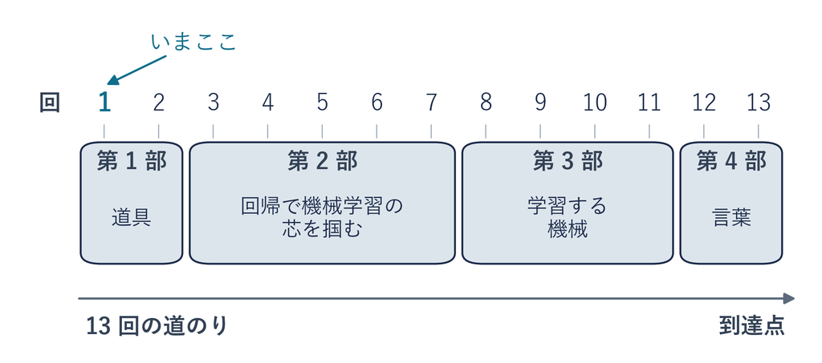

到達点：毎日使う AI チャットの中身は、この秋に学ぶ技術

## その予測は、本当に当たるのか

去年までの数字にぴったり合う予測式ができた。来月、それは当たるのか

- **手元では満点**：過ぎた月の値を、ほとんど誤差なく言い当てる
- **来月で外す**：出てきた実測値は、予測から大きく離れている
- **腕前は、どこで測るのか**：手元か、それともまだ見ていないほうか

だから最初に決める。「良いモデル」とは何を指すのか

## 二人の学生 — 過去問の丸暗記 vs 解き方の理解

✕ 過去問の答えを丸暗記

過去問を出せば満点

初めて見る問題で手が止まる

○ 解き方を理解

過去問を出しても満点

初めて見る問題にも通じる

過去問では二人とも満点。差がつくのは「初めて見る問題」

## 機械も同じ罠に落ちる — 7 点に 2 通りの線

[figure not shown]

全部通る曲線は、新しい点で大きく外す。当てはまりだけでは決められない

## 名前をつける — 過学習と汎化

用語

**過学習**＝訓練データを覚え、未知で外す  
**汎化**＝未知のデータにも通用する

- **訓練データ**：手元にあるデータ。さっきの 7 つの点
- **未知のデータ**：まだ見ていないデータ。さっきの「新しい点」
- **覚える／学ぶ**：過学習が「覚える」、汎化が「学ぶ」

良さは手元の当てはまりではなく、未知への性能で決まる

## Q&A

Q1 全部の点を通る曲線が、いちばん良いモデルか

新しい点を 1 つ足すと大きく外す。合いすぎる曲線は「覚えた」だけ

Q2 手元の誤差がゼロなら安心か

ゼロは「覚えた」印かも。未知のデータで測るまで安心できない

Q3 この問いは今日だけの話か

回帰でも、木でも、ニューラルネットでも、姿を変えて何度も出る

Q4 未知への性能は、どう測るのか

手元のデータの一部を隠して測る。秋のあいだに何度も戻ってくる

## 生成 AI の基本

**生成 AI**＝文章・コード・画像を新しく作り出す AI

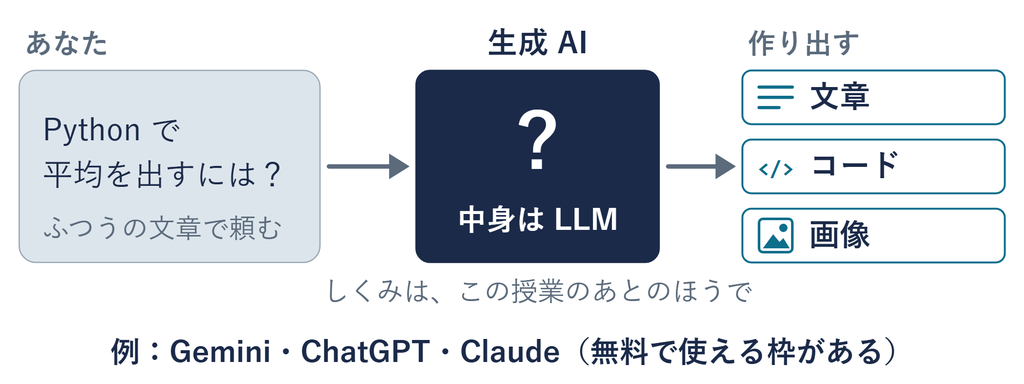

この授業では、詰まったら普段使いの生成 AI に聞く

## 詰まったときの聞き方 — エラーは全文を貼る

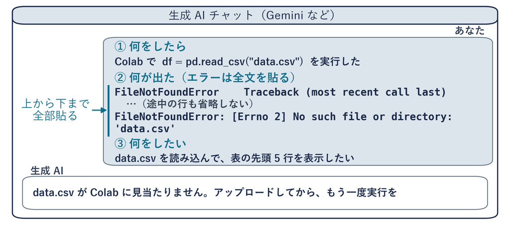

普段使っている生成 AI（Gemini など）でよい。**貼る前に自分で 1 回読む**

## AI をどこまで使うか — 3 つのゾーン

場面ごとに、AI に頼ってよい深さが決まっている

| ゾーン | ルール | 場面 |
| --- | --- | --- |
| 🟥 自力 | AI なし。自分の頭で分かったかを確かめる | 小テスト・自分の言葉で 説明する |
| 🟨 相談 | AI に聞いてよい。 コードは自分で打って検証 | 授業内のハンズオン |
| 🟩 協働 | AI フル活用可。 聞いた内容・判断・検証を記録 | 発展課題・レポート |

レポートには **AI 利用記録**の欄を書く。不使用なら「不使用」でよい

## ノートに名前をつける

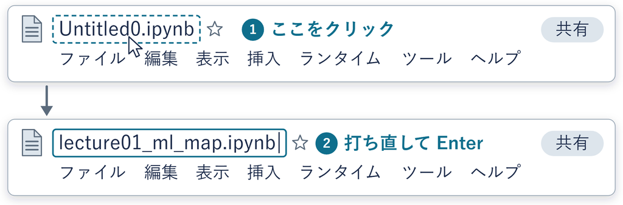

左上の `Untitled0.ipynb` をクリックして打ち直す。保存は自動

## 文章を書くセル — Markdown セル

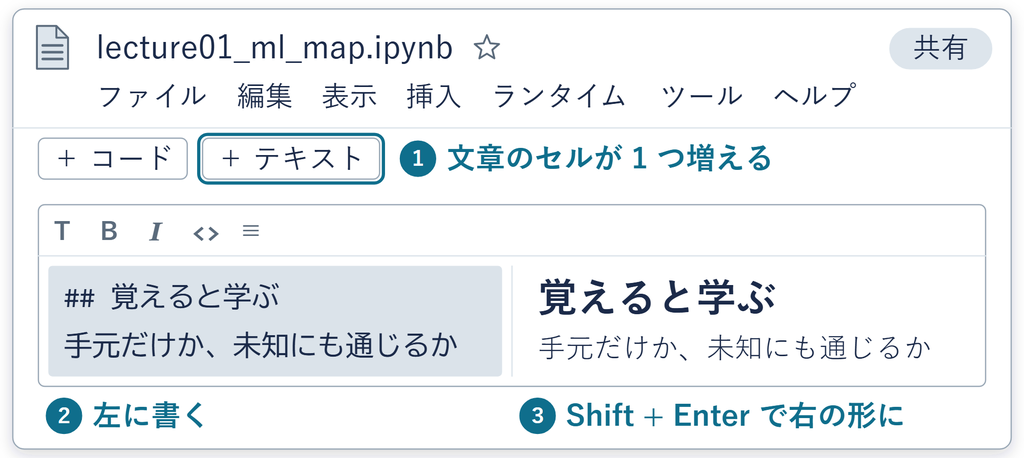

コードではなく文章を置く場所。実行すると見出しと本文に整う

## ✋ 小課題のフェーズ 1 — ノートと仮説

小課題のフェーズ 1

ノートを作り、「覚える」と「学ぶ」の違いへの仮説を書く

1. Colab で新規ノートを作り、名前を `lecture01_ml_map.ipynb` にする
2. Markdown セルに、「覚える」と「学ぶ」の違いを 2〜3 行で書く
3. 4 つのトピックで、このノートを 1 冊に育てていく

⏸ PAUSE 動画を止めて $3$ 分。書けたら再生に戻る

## まとめ — このトピックで学んだこと

- 13 回の地図は 4 つの部。  
  道具 → 回帰で機械学習の芯を掴む → 学習する機械 → 言葉
- この授業をつらぬく問い：過去問の丸暗記と、解き方の理解。  
  差がつくのは初めて見る問題
- 名前をつけた：**過学習**＝訓練データを覚えて未知で外す、  
  **汎化**＝未知にも通用する
- 生成 AI＝文章・コード・画像を作り出す AI
- 詰まったら、普段使っている生成 AI に ①何をしたら ②何が出た  
  （全文）③何をしたい の 3 行で聞く

次は **機械学習とは何か** — ルールを書くのか、データから学ぶのか

経済データとプログラミングII

第1回 — Topic02

機械学習とは何かを一行で言う

人がルールを書くか、データから学ぶか

## 第1回の道のり

1

地図と問い

演習 1-1

ノートと仮説

2

機械学習とは

演習 1-2

年表から 1 つ

3

3 つの型の地図

演習 1-3

自分の問い

4

3 行で動かす

演習 1-4

3 行を自分で

いまココ — 「機械が学ぶ」とは何かを、一行で言えるようにする

## 前トピックの振り返り

前トピックのポイント — トピック1「この授業の地図と、いちばん大事な問い」

Q: 「覚える」と「学ぶ」の違いに、何と名前をつけたか

- **過学習**: 訓練データを覚えてしまい、未知のデータで外す
- **汎化**: 未知のデータにも通用する
- **良さの物差し**: 手元の当てはまりではなく、未知への性能

名前はついた。では、その「学ぶ」の中身は何か  
今回は「機械が学ぶ」を、**一行で言う**

## このトピックで学ぶこと

- **定義**：機械学習の一行定義
- **対比**：人がルールを書くのと、何が違うか
- **歴史**：3 つのブームと 2 つの冬
- **いま**：何ができる時代に、この授業を受けているか

一行定義の中に、前のトピックの問いがそのまま入っている

## 機械学習の一行定義

定義

**機械学習**＝データから規則性を自動的に獲得し、  
未知のデータへの予測・判断を行う技術

- **データから**：ルールは人が書かず、機械が見つける
- **規則性**：どんな指標の組み合わせのときに、何が起きたか
- **未知のデータへ**：前のトピックの問いがここに入っている

手元のデータを覚えるだけなら、学んだとは言わない

## 人がルールを書く／データから規則を学ぶ

[figure not shown]

ルールは人が書く**入力**、規則は機械が見つける**出力**。立場が逆

## なぜ機械に学ばせるのか

「失業率↑・株価↓・求人↓なら黄信号」——このルールを人が全部書けるか

言葉にできない

何が効くかを  
専門家も言えない

古びる

構造が変わると  
ルールが外れる

多すぎる

組み合わせが  
爆発して書けない

だから、データから規則を取り出す道具が要る。人の直観を補う道具

## 略史 — 3 つのブームと 2 つの冬

[figure not shown]

期待と幻滅を繰り返して今日へ。対話型 AI はこの系譜の先端

## 歴史の各段は、この授業のどこに出るか

年表の出来事は、この授業で手に入れる道具に対応する

| 歴史の段 | 何が起きたか | この授業で |
| --- | --- | --- |
| パーセプトロン | 最初期の「学習する機械」 | ニューラルネットの回 |
| 誤差逆伝播 | 多層のネットを訓練する仕組み | ニューラルネットの回 |
| SVM・アンサンブル | 統計的手法の成熟 | 木とアンサンブルの回 |
| 深層学習 | 画像認識で飛躍 | ニューラルネットの回 |
| Transformer・LLM | 文脈を読む仕組み | 言葉のデータの回 |

歴史の順に、道具を手に入れていく

## Q&A

Q1 機械学習＝AI が全部自動でやってくれる、か

問いを立て、データを用意し、結果を読むのは人

Q2 ルールを書くのは、常に劣るのか

言葉にできるならルールでよい。消費税の計算に学習は不要

Q3 データが無くても学べるか

データが無ければ規則は取り出せない（定義の最初の語）

Q4 一度学べば、ずっと使えるか

経済の構造が変われば学び直す。データを与え直せば更新

## ✋ たしかめ — どれが機械学習か

たしかめ

次の 4 つのうち、機械学習はどれか

① 消費税を計算するプログラム ② 迷惑メールの自動判定  
③ 来月の電力需要の予測 ④ 駅の券売機の運賃表

1. 一行定義の「データから」に当てて、当てはまるものを全部選ぶ
2. 選んだものを紙に書く。次のスライドで答え合わせ

⏸ PAUSE 動画を止めて $1$ 分。選んだら再生に戻る

## たしかめの答え — 一行定義に当てる

① 消費税 ② 迷惑メール ③ 電力需要 ④ 運賃表

① どこを見る

人がルールを  
書けるか

② 使う道具

一行定義の  
「データから」

③ 当てはめる

①④はルール  
②③は例から学ぶ

こたえ

**②と③が機械学習**

④の運賃表は答えの表。表を引くだけならルールでよい

## ✋ 小課題のフェーズ 2 — 年表から 1 つ

小課題のフェーズ 2

年表から出来事を 1 つ選び、何が学習を可能にしたかを書く

1. 年表の 7 つの出来事から、気になるものを 1 つ選ぶ
2. Markdown セルに、出来事と「学習を可能にしたもの」を 1〜2 行
3. 教科書の略史を読み直してよい。自分の言葉で書く

⏸ PAUSE 動画を止めて $2$ 分。書けたら再生に戻る

## まとめ — このトピックで学んだこと

- **機械学習**＝データから規則性を自動的に獲得し、  
  未知のデータへの予測・判断を行う技術
- ルールは人が書く入力、規則は機械が見つける出力。立場が逆
- 機械に学ばせる理由：言葉にできない・古びる・多すぎる
- 略史は 3 つのブームと 2 つの冬。各段がこの授業の道具に対応する
- ルールが言葉にできるならルールでよい。  
  データが無ければ学べない

次は **機械学習の地図** — 3 つの型（回帰・分類・クラスタリング）を仕分ける

経済データとプログラミングII

第1回 — Topic03

問いを 3 つの型に仕分ける

回帰・分類・クラスタリングの地図

## 第1回の道のり

1

地図と問い

演習 1-1

ノートと仮説

2

機械学習とは

演習 1-2

年表から 1 つ

3

3 つの型の地図

演習 1-3

自分の問い

4

3 行で動かす

演習 1-4

3 行を自分で

いまココ — 経済の問いを、回帰・分類・クラスタリングの 3 つの島に置く

## 前トピックの振り返り

前トピックのポイント — トピック2「機械学習とは何かを一行で言う」

Q: 機械学習を一行で言うと

- **データから**: ルールは人が書かず、機械が見つける
- **規則性を獲得**: どんな組み合わせのときに何が起きたか
- **未知のデータへ**: 予測・判断を行う。手元を当てるだけでは足りない

定義は 1 つでも、その定義で扱える問いは 1 つではない  
今回は「**何を予測するか**」で、問いを 3 つの型に仕分ける

## このトピックで学ぶこと

- **2 本の軸**：学び方の軸 × タスクの軸
- **教師**：正解データがあるか、ないか
- **3 つの型**：回帰・分類・クラスタリング
- **仕分け**：経済の問いも、ゼミのアンケートも、まず型を決める

型が決まらないと、使う道具も、当たったかの測り方も決まらない

## 地図は 2 本の軸でできている

用語

**学び方の軸**＝正解データを使うか  
**タスクの軸**＝何を当てるか

- **学び方の 3 つ**：教師あり／教師なし／強化
- **使うのは 2 つ**：教師あり・教師なし。強化学習はこの授業では扱わない
- **タスクの 3 つ**：回帰／分類／クラスタリング
- **混ぜやすい**：「分類」と「教師あり」を同じ意味で使いがち。軸が違う

まず「正解データがあるか」を見る。次に「何を当てるか」を見る

## 教師とは正解データのこと

定義

**教師あり学習**＝正解データつきの例を大量に見せて学ばせる  
**教師なし学習**＝正解データなしで、まとまりを見つけさせる

- **教師ありの例**：失業率（入力）と物価上昇率（正解データ）の組
- **教師なしの例**：47 都道府県を似た者同士に（正解データなし）
- **強化学習**：行動と報酬で学ぶ型。この授業では扱わない

教師ありと教師なしの違いは、正解データがあるかどうか

## 3 つの型 — 回帰・分類・クラスタリング

定義

**回帰**＝連続値（何%か・いくらか）を当てる  
**分類**＝カテゴリ（A か B か）を当てる  
**クラスタリング**＝正解データなしにグループに分ける

- **回帰**：来期の成長率は何%か。数値そのものを当てる
- **分類**：来期は景気後退か否か。区分のどれかを当てる
- **クラスタリング**：47 都道府県を似た者同士に。正解データが無い

前の 2 つは教師あり、最後の 1 つは教師なし

## 2 本の軸の地図

[figure not shown]

縦が学び方、横がタスク。この地図は決めた言葉で読める

## 同じデータでも、問いが型を決める

失業率の並びを前にして、どう問うか。問い方で型が変わる

| 問い | 型 | 予測するもの |
| --- | --- | --- |
| 来期の失業率は何%か | 回帰 | 連続値 |
| 来期は失業率が悪化するか | 分類 | カテゴリ |
| どの都道府県が似ているか | クラスタリング | グループ |
| 決算文書（業績を説明する文書）は前向きか | 分類 | カテゴリ |

**問いが決める。データが決めるのではない**  
言葉は数値に直してから分類する

## Q&A

Q1 分類とクラスタリングは同じ（どちらもグループ分け）か

正解データがあるのが分類、ないのがクラスタリング

Q2 数値を扱えば回帰か

0 と 1 は「後退する／しない」に付けた印で、  
大小に意味がない。だから分類

Q3 教師あり＝先生が教える、か

教師とは正解データのこと。人が横で教えるわけではない

Q4 型を間違えると、何が起きるか

道具の選び方と精度の測り方が全部変わる。だから最初に仕分ける

## ✋ たしかめ — 提出率は何問題か

たしかめ

「来週の宿題の提出率（%）を予測する」は、どの型か

1. 過去の提出記録から、提出率（%）を当てる。どの型か紙に書く
2. 「ある学生が提出するか否か」は、どれか。こちらも紙に書く
3. 配布したスライドの中のデモで、12 枚を島に置いて答え合わせ

⏸ PAUSE 動画を止めて $1$ 分。予想を決めたら再生に戻る

## デモ：12 枚を 3 つの島へ

見分け方

連続値 → 回帰・カテゴリ → 分類  
正解データなし → クラスタリング

- **何を見るか**：12 枚のカードを 3 つの島に置く
- **図の意味**：真ん中に 3 つの島、下にまだ置いていないカード
- **操作**：カードを島へドラッグ。置くと ○ か ✕ が出る

ミッション 提出率(%) と 提出するか否か のカードを正しい島へ

※ 次のスライドへ進むときは、デモの枠の外を一度クリックしてから ← → キーを押す

[interactive chart not shown]

## たしかめの答え — 数か、区分か

「提出率は何%か」と「提出するか否か」は、どの型か

① どこを見る

数か、区分か  
正解データの有無

② 使う決まり

回帰＝連続値  
分類＝カテゴリ

③ 当てはめる

提出率 → 回帰  
するか否か → 分類

こたえ

提出率は回帰、提出するか否かは分類

どちらも過去の提出記録（正解データ）から学ぶので教師あり

## 3 つの島 — 12 枚の置き場

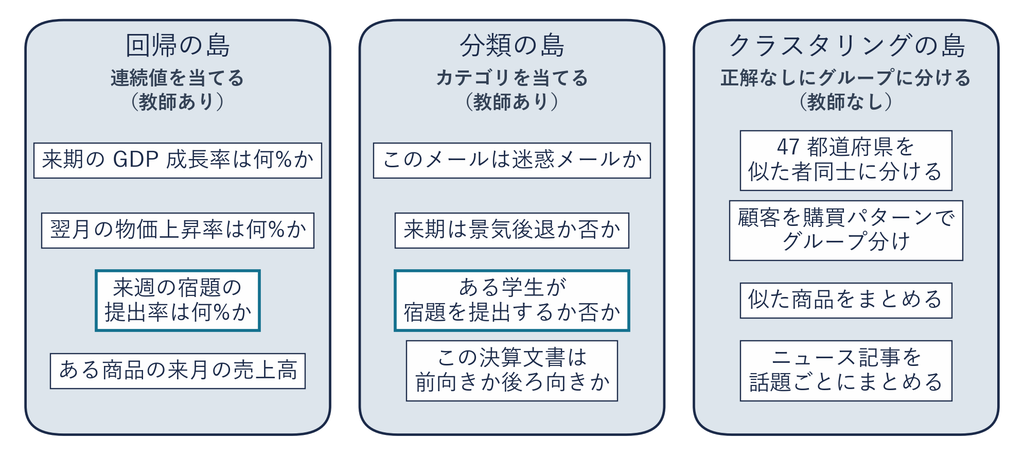

同じ「提出」でも、問いが違えば島が違う（濃い枠の 2 枚）

## ✋ 小課題のフェーズ 3 — 自分の問い

小課題のフェーズ 3

予測したい問いを 1 つ挙げ、型を理由つきで書く

1. 予測したい問いを 1 つ決める（株価、受かるか否か、似た店）
2. 当てるものは連続値か、カテゴリか、正解データなしのグループか
3. 自分のノートの Markdown セル（文章を書くセル）に、3 行で書く

⏸ PAUSE 動画を止めて $3$ 分。書けたら再生に戻る

## まとめ — このトピックで学んだこと

- 地図は 2 本の軸。学び方（教師あり／教師なし／強化）× タスク  
  （回帰／分類／クラスタリング）
- 教師とは正解データのこと。あるのが教師あり、ないのが教師なし
- **回帰**＝連続値（何%か）を当てる、**分類**＝カテゴリ（A か B か）  
  を当てる、**クラスタリング**＝正解データなしにグループに分ける
- 型を決めるのは問い。同じ失業率の並びでも「何%か」なら回帰、  
  「悪化するか」なら分類
- 提出率（%）は回帰、提出するか否かは分類。  
  同じ「提出」でも島が違う

次は **3 行で「学習」を動かす** — scikit-learn で回帰を 1 回

経済データとプログラミングII

第1回 — Topic04

3 行で「学習」を動かす

scikit-learn の fit と predict

## 第1回の道のり

1

地図と問い

演習 1-1

ノートと仮説

2

機械学習とは

演習 1-2

年表から 1 つ

3

3 つの型の地図

演習 1-3

自分の問い

4

3 行で動かす

演習 1-4

3 行を自分で

いまココ — scikit-learn の 3 行で、失業率から物価上昇率を予測する

## 前トピックの振り返り

前トピックのポイント — トピック3「問いを 3 つの型に仕分ける」

Q: 回帰と分類は、何が違ったか

- **回帰**: 連続値を当てる。「来期は何%か」
- **分類**: カテゴリを当てる。「悪化するか否か」
- **問いが型を決める**: データが決めるのではない

地図を描いたら、次は歩く番  
今回は **回帰** を 1 回動かす。失業率から物価上昇率を当てる

## このトピックで学ぶこと

- **Colab**：ブラウザで動く作業場。ノートを開き、道具を import する
- **3 段の型**：モデルを作る → fit → predict
- **体験**：6 年分の失業率から、物価上昇率を予測する
- **読み方**：出てきた数を、因果ではなく「関連」として読む

この 3 段は、秋のあいだどの手法でも同じ形で出てくる

## Colab とは — ブラウザの中の Python

用語

**Google Colab**＝ブラウザの中で Python を書いて動かせる作業場

- **入れるものは無い**：Google のアカウントで開くだけ。  
  手元の機械に何も入れない
- **置き場は Google ドライブ**：作ったノートは自動で保存さ  
  れ、次も同じ場所から開く
- **ノートはセルの集まり**：コードのセルと文章のセル  
  （Markdown セル）の 2 種類

計算するのは手元の機械ではなく、Google の機械

## Colab の画面 — 4 つの場所

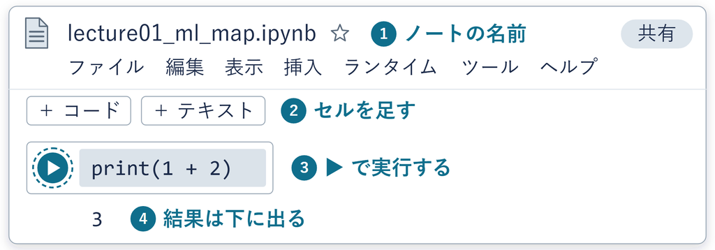

セルを選んで ▶（Shift + Enter は**実行して次のセルへ**）。結果はその下に出る

## 今日のノートを開いて import

```python
import numpy as np
from sklearn.linear_model import LinearRegression
```

**やること**：今日のノート `lecture01_ml_map.ipynb`（まだ無ければ新しく作って名前を付ける）  
を開き、コードセルにこの 2 行を書いて ▶ で実行。最初の 1 回だけ、  
つながるまで少し待つ。エラーなく終われば準備完了  
**用語**：1 行目は**道具箱ごと**呼ぶ書き方（`import ...`）、2 行目は**道具箱の中から 1 つだけ**呼ぶ書き方  
（`from ... import ...`）。`as np` は**あだ名をつける**書き方で、以降 `numpy` を `np` と書ける。`numpy` は数の並びを扱う道具、機械学習の道具箱は名前が **scikit-learn** でコードでは **`sklearn`** と書く

## scikit-learn の型はいつも 3 段

法則

**① モデルを作る → ② fit（訓練する）→ ③ predict（予測する）**

- **作る**：モデル＝データに当てはめる「形」を決める。今日は直線
- **fit**：手元のデータに最もよく合う形を選ぶ。これが「学習」
- **predict**：未知の入力に対する答えを出す

どう測って「最もよく合う」を決めるかは、  
この先で扱う。今日は直線で 1 回まわす

## 3 段の流れ

[figure not shown]

手元のデータで学び（fit）、未知の入力に答える（predict）

## データを用意する — 失業率と物価上昇率

```python
# 出典: 総務省統計局『労働力調査』『消費者物価指数』（年平均）
# 失業率(%) と 物価上昇率(%)。今日は値をそのまま与える
unemployment = [2.09, 2.89, 3.40, 4.42, 4.73, 5.36]
cpi          = [2.88, 0.76, 0.68, -0.13, -0.32, -0.82]

X = np.array(unemployment).reshape(-1, 1)  # 説明変数は縦に並べるのが作法
y = np.array(cpi)
```

**このセルをノートに書いて ▶ で実行**（さきほどの import の下に足す）  
`np.array(...)` は Python のリストを **NumPy の配列**（数を並べて入れる箱）  
に変える。**大文字の** `X`：**説明変数**（予測に使う側・失業率）  
を表の形にしたもの。`y`：当てたいもの（物価上昇率）  
`reshape(-1, 1)` が何をしているかは次の 2 枚で絵にする

## リストと二重リスト

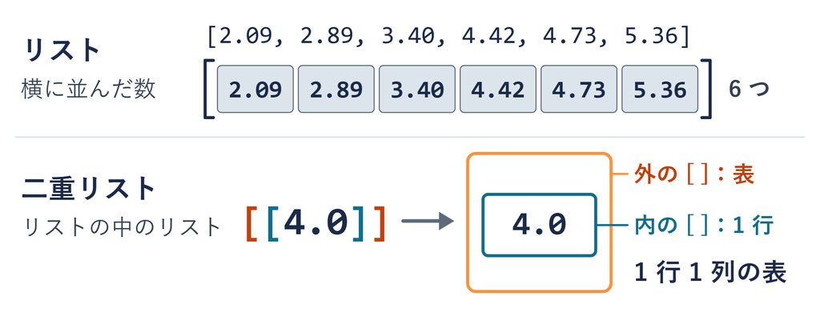

内側の `[ ]` 1 つが表の 1 行。`[[4.0]]` は 1 行 1 列の表

## reshape と二重カッコの理由

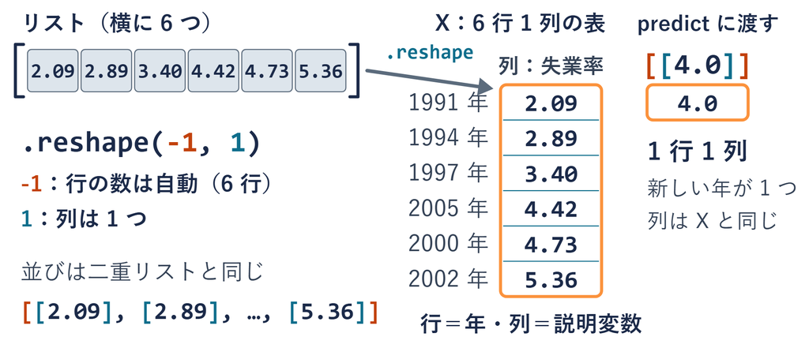

scikit-learn は `X` を表で受け取るので、`predict` にも表 `[[4.0]]` を渡す

## 核心の 3 行 — 作る・fit・predict

```python
model = LinearRegression()   # (1) モデルを作る
model.fit(X, y)              # (2) 訓練する（fit）：データから直線を学ぶ
# (3) 予測する（predict）：未知の失業率4.0%に対して
model.predict([[4.0]])
# → array([0.32...])
```

**このセルもノートに書いて ▶ で実行**（データのセルの下に足す）  
`LinearRegression`：直線を当てはめるモデル  
`fit` で直線を選び、6 点にない 4.0% にも答えを出した  
**セルの最後の行の値は、`print` を書かなくてもその下に出る**

## 学習した直線 — 関連であって因果ではない

[figure not shown]

失業率が $1$ ポイント高い年は、物価上昇率が約 $1$ ポイント低い

## 直線を式で書く — 関連と因果はどう違うか

学習した直線

**物価上昇率 $\approx -1.00 \times$ 失業率 $+\ 4.32$**

- **傾き $-1.00$**：失業率が $1$ ポイント高い年は、  
  物価上昇率が約 $1$ ポイント低い
- **縦軸のマイナス**：物価が下がった年という意味  
  （データの誤りではない）
- **関連**：2 つが一緒に動くこと。  
  **因果**：片方がもう片方を変えたと示すこと

この $6$ 点だけでは他の要因を除けないので、言えるのは関連まで

## Q&A

Q1 `NameError: name 'model' is not defined` はなぜ出るか

そのセルをまだ実行していない。ノートの上から順に ▶ を押し直す

Q2 `ValueError: Expected 2D array` はどう直すか

`X` は `reshape(-1, 1)` で 6 行 1 列  
`predict` は二重カッコ `[[4.0]]` で 1 行 1 列。どちらも表の形で渡す

Q3 `fit` の前に `predict` してよいか

順番は 作る → fit → predict（学ぶ前に答えは出せない）

Q4 出力の `array([...])` は何か

numpy の配列で、中の数が予測値（入力 1 つなら数も 1 つ）

## ✋ たしかめ — 失業率 3.0% ならどれだけ上か

たしかめ

失業率を 1 ポイント下げる（4.0% → 3.0%）と、  
物価上昇率の予測はどれだけ上がるか

1. 予想を紙に書く：ちょうど $1.00$ 上がる／それより多い／少ない
2. `model.predict([[3.0]])` を実行  
   `[[ ]]` に入れるのは**失業率**、出てくるのは**物価上昇率の予測**
3. 逆に 1 ポイント上げた `[[5.0]]` も実行（同じだけ下がるか）

⏸ PAUSE 動画を止めて $2$ 分。自分の Colab で実行したら再生に戻る

## たしかめの答え — 3 点は同じ直線の上

[figure not shown]

失業率 3.0% → 予測 約 $1.32$%（$1.00$ 上がる）、5.0% → 約 $-0.68$%（$1.00$ 下がる）

## ✋ 小課題のフェーズ 4 — 3 行を自分で

小課題のフェーズ 4

3 行を自分のノートで動かし、  
自分で決めた失業率を 1 つ predict する

1. データのセルと核心の 3 行を、今日のノートに写して実行
2. 失業率を自分で 1 つ決めて `model.predict([[ ]])` に入れ、値を出す
3. Markdown セルに、出た値と「なぜその値になるか」を、  
   **傾き $-1.00$ の直線**を使って 2〜3 行

⏸ PAUSE 動画を止めて $3$ 分。書けたら再生に戻る

## まとめ — このトピックで学んだこと

- scikit-learn の型はいつも 3 段：**モデルを作る → fit → predict**
- `X` は説明変数を縦に並べたもの、`y` は当てたいもの
- `fit(X, y)` で、6 点に最もよく合う直線が選ばれた
- `predict([[4.0]])` で、6 点にない失業率に 約 0.32% を出した
- 傾きは約 $-1.00$。  
  失業率が高い年ほど物価上昇率が低い**関連**で、**因果**ではない

今日は整った 6 点をあらかじめ用意しておいた。現実の経済データは汚れている  
**整ったデータをどう作るかは、この先の授業で扱う**